# KrisGuide Signboard Recognition Jupyter Notebook Demo

This is a demo for the Singapore Airline App Challenge (Optical Signboard Recognition Part). Below is the input picture to be tested.

# Introduction

There are several methods of conducting signboard recognition. One very "buzzword" solution is to directly use Convolutional Neural Network to extract all the features and directly store into the database for matching. The problem is that direct use of CNN takes hundreds, if not thousands of image samples to train an accurate model. We cannot go to Changi Airport just to take all these signage pictures. Also, the computation is too heavy, topping up your AWS bill too expensive to sustain.

[output not shown]

As for logo extraction, SIFT is a great pattern extraction and mapping algorithm that are used extensively. However, we cannot use SIFT for this case because SIFT is patent protected, and kicked out of the OpenCV libraries. There are several other logo extraction algorithms, like KAZE and ORB. Unfortunately, after countless testing, it still failed to perform a highly accurate icon recognition. KAZE and ORB requires a high complexity of the features to function, as there are too many other matching features in the sample pictures. It was concluded that CNN is necessary, but the training part has to be minimised with some tricks.

We first recognise the black signboard using prebuilt comvolutional neural network in the AWS Rekognition. The signboard image is preprocessed to obtain the features, and then it is warped and cropped a standard rectangle shape to have a front-facing image. After that, OCR and Icon recognition is conducted. OCR is a mature technology that is available from the AWS Rekognition API/Google Vision AI as well. As for the Icon recognition, we have tailor made a icon recognition CNN model for Changi Airport. This CNN can be firther developped into all-airports-in-one icon recognition model in the future.

# Step 0: Upload Local Image to AWS S3 (Storage System)

Be it the final app is in the form of a camera or AR app, image has to be stored in the AWS S3 in order to be processed in AWS Rekognition, the machine-learning based image recognition service.

```
Uploading Image, takes up to 10 secs
```

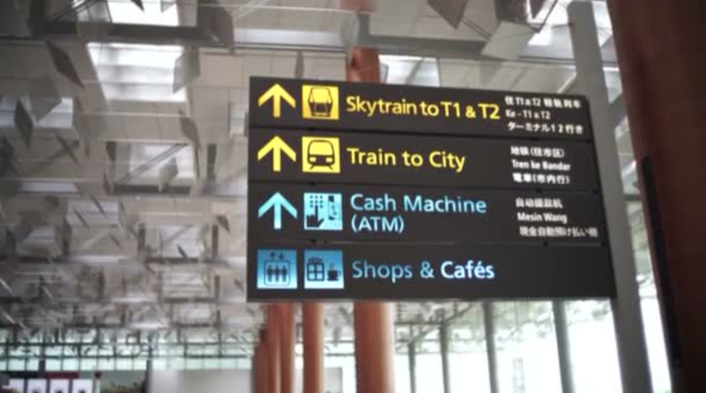

```
Uploaded Image
```

```python
from PIL import Image, ImageFilter, ImageEnhance
from IPython.display import Image as displayImage
from IPython.display import display
import cv2
import numpy as np
from matplotlib import pyplot as plt
import imutils
import boto3

selected = 'sign2'
url = 'img/raw/'+selected+'.png'

s3 = boto3.resource('s3')
data = open(url, 'rb')
print("Uploading Image, takes up to 10 secs")
img = cv2.imread(url)
s3.Bucket('krisguideimages').put_object(Key='test.png', Body=data)
display(displayImage(url))
print("Uploaded Image")
```

# Step 1: AWS Signboard "Rekognition"

AWS Rekognition is a prebuilt image classifier/recogniser that can identify million types of objects in the images thanks to the prebuilt deep neural network. It is used here to recognise the position of the signboard, minimising the scope of computation on the images.

```
Signboard detected, confidence level: 97.87%
1208 672
0.5870323181152344 0.630614697933197 0.30521199107170105 0.17561152577400208
```

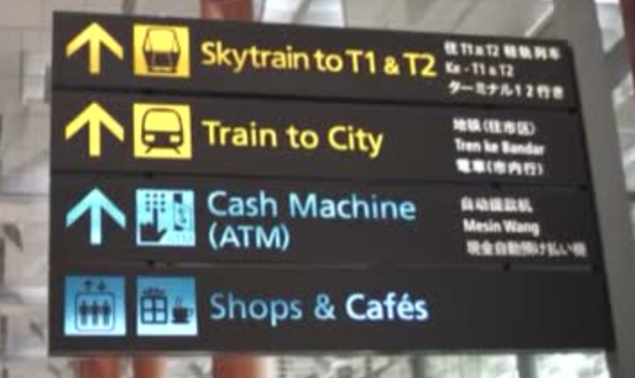

```python
import json

client = boto3.client('rekognition')

response = client.detect_labels(
    Image={
        'S3Object': {
            'Bucket': 'krisguideimages',
            'Name': 'test.png',
        },
    },
)

NOSCOREBOARD=1
for item in response['Labels']:
    if item['Name']=="Scoreboard":
        NOSCOREBOARD=0
        w = item['Instances'][0]['BoundingBox']['Width']
        h = item['Instances'][0]['BoundingBox']['Height']
        l = item['Instances'][0]['BoundingBox']['Left']
        t = item['Instances'][0]['BoundingBox']['Top']
        c = item['Instances'][0]['Confidence']
        s = "%5.2f" % c
        print("Signboard detected, confidence level: "+s+"%")

height, width, channels = img.shape

print(width, height)
print(w,h,l,t)
x1 = int(width*l)
y1 = int(height*t)
x2 = int(width*(l+w))
y2 = int(height*(t+h))

crp = img[y1:y2, x1:x2]

cv2.imwrite('img/processed/crp.png',crp)
display(displayImage('img/processed/crp.png'))


if NOSCOREBOARD:
    print("No Signboard detected")
```

# Step 2: Image Preprocessing

Since pictures are often over/underexposed, histogram equalisation is adopted to normalise the intensity of the images. Several Operations are made to extract the features of the images.

- Histogram Equalisation
- Thresholding (Extract signboard shape&orientation)
- Edge Dilation and Erosion

[figure not shown]

- Image Preprocessing
- Warp Signage to front facing image
- Conduct OCR, recognise texts and its bounding box position/orientation

From testing, it was found that adaptive threshold was not a good way of thresholding the features of the signboard, because the signboard contained bright texts which affected the local area averate brightness processed by the kernel.

Edge detection was also tested and found to be useless in this case, as the histogram equalisation has already emphasised the features of the signboard, making it capable of extracting the features directly.

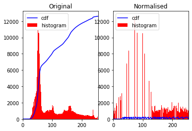

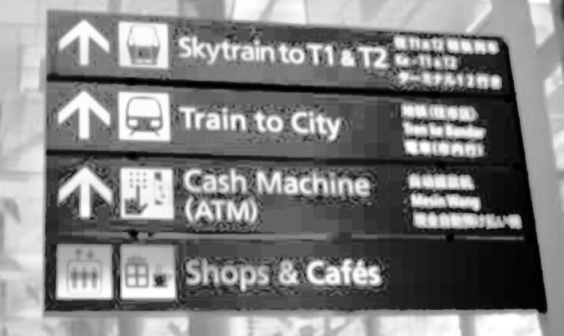

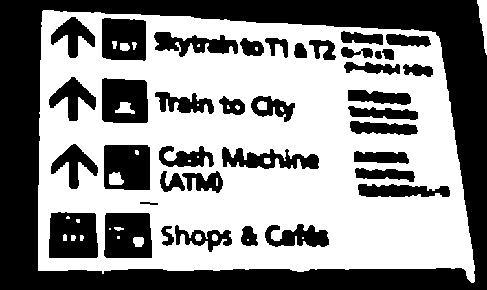

```python
img = cv2.imread('img/processed/crp.png',0)#image selected
imgCol = cv2.imread('img/processed/crp.png')#image selected
imgCpy = img

hist,bins = np.histogram(img.flatten(),256,[0,256])
cdf = hist.cumsum()
cdf_normalized = cdf * hist.max()/ cdf.max()

plt.subplot(1,2,1)
plt.plot(cdf_normalized, color = 'b')
plt.hist(img.flatten(),256,[0,256], color = 'r')
plt.xlim([0,256])
plt.legend(('cdf','histogram'), loc = 'upper left')
plt.title("Original")

cdf_m = np.ma.masked_equal(cdf,0)
cdf_m = (cdf_m - cdf_m.min())*255/(cdf_m.max()-cdf_m.min())
cdf = np.ma.filled(cdf_m,0).astype('uint8')
equ = cv2.equalizeHist(imgCpy)
cdf_normalized = cdf * hist.max()/ cdf.max()

plt.subplot(1,2,2)
plt.plot(cdf_normalized, color = 'b')
plt.hist(equ.flatten(),256,[0,256], color = 'r')
plt.xlim([0,256])
plt.legend(('cdf','histogram'), loc = 'upper left')
plt.title("Normalised")
plt.show()
cv2.imwrite('img/processed/equ.png',equ)

##############################
equ = cv2.medianBlur(equ,3)
cv2.imwrite('img/processed/equ.png',equ)
display(displayImage('img/processed/equ.png'))


thr_val = 135
ret, thr = cv2.threshold(equ, thr_val, 255, cv2.THRESH_BINARY)
#thr = cv2.adaptiveThreshold(equ,255,cv2.ADAPTIVE_THRESH_GAUSSIAN_C, cv2.THRESH_BINARY,11,5)

neg = 255-thr

kernel = np.ones((2,2), np.uint8)
neg = cv2.erode(neg,kernel,iterations = 1)

kernel = np.ones((5,5), np.uint8)
dil = cv2.dilate(neg, kernel, iterations=1)

kernel = np.ones((3,3), np.uint8)
ero = cv2.erode(dil,kernel,iterations = 1)
cv2.imwrite('img/processed/ero.png', ero)



#display(displayImage('img/processed/equ.png', height=50, unconfined=True))
display(displayImage('img/processed/ero.png'))
```

## Step 3: Singboard Perspective Warp

In order to minimise the traning image set size of the signbard icons, the flat signboard surface was extracted to obtain a front facing image, like the one below.

2 approaches to detecting rectangles:

- Contour Detection: Find the contour
- Hough Line Detection: find straight lines, detect 4 intersecting points leading to a rectangle

Contour Detection as shown above is made possible in our use case thanks to the Step 1 and 2. This is because area of the background of the signboard is minimised and the Histogram Equalisation is carried out, highlighting the features of the signboard.

Hough Line is another common method of finding the rectangle corners. It probablistically find the best fit lines in the whole picture, then finds 4 junctions for a rectangle. problem with this solution is that quite often the silhoutette of the signboard is not in the shape of perfect rectangle, with some diconnected contours in the singboard. Although it can set some values to cover these flaws, inappropriate setting of the parameters often leads to moo many or less hough lines, leading to likelihood in misalignment.

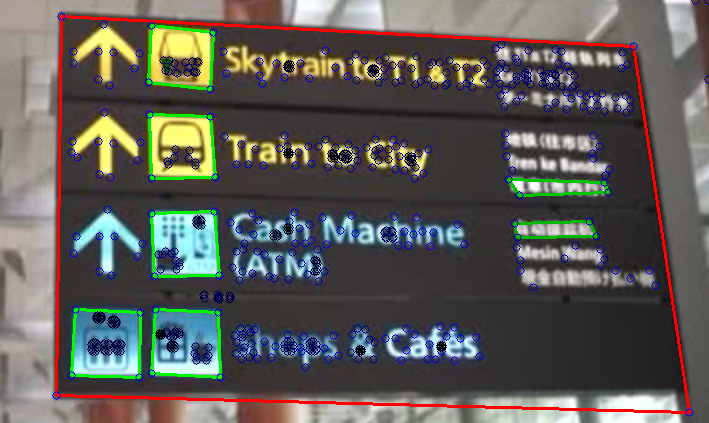

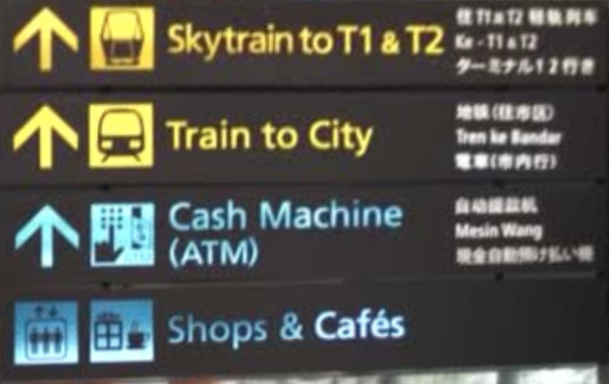

```python
def transform_by4(img, points):
	""" 4点を指定してトリミングする。 """
	points = sorted(points, key=lambda x:x[1])  # yが小さいもの順に並び替え。
	top = sorted(points[:2], key=lambda x:x[0])  # 前半二つは四角形の上。xで並び替えると左右も分かる。
	bottom = sorted(points[2:], key=lambda x:x[0], reverse=True)  # 後半二つは四角形の下。同じくxで並び替え。
	points = np.array(top + bottom, dtype='float32')  # 分離した二つを再結合。

	width = max(np.sqrt(((points[0][0]-points[2][0])**2)*2), np.sqrt(((points[1][0]-points[3][0])**2)*2))
	height = max(np.sqrt(((points[0][1]-points[2][1])**2)*2), np.sqrt(((points[1][1]-points[3][1])**2)*2))

	dst = np.array([
			np.array([0, 0]),
			np.array([width-1, 0]),
			np.array([width-1, height-1]),
			np.array([0, height-1]),
			], np.float32)

	trans = cv2.getPerspectiveTransform(points, dst)  # 変換前の座標と変換後の座標の対応を渡すと、透視変換行列を作ってくれる。
	return cv2.warpPerspective(img, trans, (int(width), int(height)))  # 透視変換行列を使って切り抜く。
'''
dil2 = 255-dil

cv2.imwrite('img/processed/dil2.png', dil2)
display(displayImage('img/processed/dil2.png'))
'''


cnts = cv2.findContours(ero, cv2.RETR_LIST, cv2.CHAIN_APPROX_SIMPLE)[0]  # 抽出した輪郭に近似する直線を探す。
cnts.sort(key=cv2.contourArea, reverse=True)  # 面積が大きい順に並べ替える。

flag=0
lines=imgCol.copy()
for i, c in enumerate(cnts):
    arclen = cv2.arcLength(c, True)
    approx = cv2.approxPolyDP(c, 0.02 * arclen, True)

    level = 1 - float(i) / len(cnts)  # 面積順に色を付けたかったのでこんなことをしている。
    if len(approx) == 4:
        cv2.drawContours(lines, [approx], -1, (0, 0, 255 * level), 2)
        if flag == 0:#No array formed
            warp = approx.copy()  # 一番面積の大きな四角形をwarpに保存。
            flag=1
        else:
            cv2.drawContours(lines, [approx], -1, (0, 255 * level, 0), 2)
    for pos in approx:
        cv2.circle(lines, tuple(pos[0]), 4, (255 * level, 0, 0))

cv2.imwrite('img/processed/lin.png', lines)
display(displayImage('img/processed/lin.png'))

if flag != 0:
    war = transform_by4(imgCol, warp[:, 0, :])  # warpが存在した場合、そこだけくり抜いたものを作る。
    cv2.imwrite('img/processed/war.png', war)
    display(displayImage('img/processed/war.png'))
else:
    print("No Contour detected")
```

# Step 3: AWS Rekognition Text in Image (OCR)

OCR is readily available in the AWS Rekognition Package.

```python
s3 = boto3.resource('s3')
warpURL = 'img/processed/war.png'

data = open(warpURL, 'rb')
print("Uploading image, takes up to 10 secs, in real case it will be directly accessed by AWS Rekognition without upload")
img = cv2.imread(warpURL)
s3.Bucket('krisguideimages').put_object(Key='warp.png', Body=data)
#display(displayImage(warpURL))

string = "";
print("Uploaded image, recognised text will be shown below in 2 secs:")
client = boto3.client('rekognition')
response = client.detect_text(Image={'S3Object':{'Bucket':'krisguideimages', 'Name':'warp.png'}})
#print(response)
for item in response['TextDetections']:
    if item['Type']=='LINE' and item['Confidence']>90.0:
        string = string+'\n'+item['DetectedText']

print(string)
```

```
Uploading image, takes up to 10 secs, in real case it will be directly accessed by AWS Rekognition without upload
Uploaded image, recognised text will be shown below in 2 secs:

Skytrain to T1 & T2 & -11612
Train to City Tran e Randar
Cash Machine 14026
Mesin Wang
(ATM)
Shops & Cafes
```

# Step 4: Icon Recognition with Google AutoML Vision (Building own CNN)

While AWS Rekognition has a nice image recognition package, its still cannot recognise icons and arrows in the signboard. For that, we need to build our own Convolutional Neural Network (CNN). Usually CNN at accuracy of 95%+ is built with image set size in thousandth order. however, as we have already warped the signage to be front facing, we can limit the size of the icon recognition at order of tenths. Building CNN with Vision AI is very straight forward.

First, icons and arrows of the signboard is collected from Google Image Search screenshots. these icons are categorised by its name.

[figure not shown]

Then, the images are loaded to the Google AutoML Vision (Object Detection) and text labels are assigned. These datasets will automatically be divided into 8:1:1 ratio(Train,Test,Validate).

[figure not shown]

After that, press the "train model button" and wait for about an hour for training the model.

In thid demo, only the front arrow and lift is modelled because there were insufficient images (less than 10) of the elevators and other arrows.

```python
# TODO(developer): Uncomment and set the following variables
# project_id = 'PROJECT_ID_HERE'
# compute_region = 'COMPUTE_REGION_HERE'
# dataset_name = 'DATASET_NAME_HERE'
# multilabel = True for multilabel or False for multiclass

from google.cloud import automl_v1beta1 as automl

client = automl.AutoMlClient()

# A resource that represents Google Cloud Platform location.
project_location = client.location_path(project_id, compute_region)

# Classification type is assigned based on multilabel value.
classification_type = "MULTICLASS"
if multilabel:
    classification_type = "MULTILABEL"

# Specify the image classification type for the dataset.
dataset_metadata = {"classification_type": classification_type}
# Set dataset name and metadata of the dataset.
my_dataset = {
    "display_name": krisGuide,
    "image_classification_dataset_metadata": dataset_metadata,
}

# Create a dataset with the dataset metadata in the region.
dataset = client.create_dataset(project_location, my_dataset)

# Display the dataset information.
print("Dataset name: {}".format(dataset.name))
print("Dataset id: {}".format(dataset.name.split("/")[-1]))
print("Dataset display name: {}".format(dataset.display_name))
print("Image classification dataset metadata:")
print("\t{}".format(dataset.image_classification_dataset_metadata))
print("Dataset example count: {}".format(dataset.example_count))
print("Dataset create time:")
print("\tseconds: {}".format(dataset.create_time.seconds))
print("\tnanos: {}".format(dataset.create_time.nanos))
```

# Step 5: Query Signboard ID with its Context

Now that we have both the directions and the facilities listed in the signboard, we can use these data to do a query on its signboard ID. Now the texts obtained from OCR might have several problems, such as misreading some texts and spaces. For that, instead of directly comparing the string, SequenceMatcher library is used. A scale from 0.0 (no match) to 1.0 (fully matched) is derived and compared.

similar("Apple","Appel")  
0.8  
similar("Apple","Mango")  
0.0

```python
from difflib import SequenceMatcher

def similar(a, b):
    return SequenceMatcher(None, a, b).ratio()

#similar (string, text)

texts = ["",
         "Arrival Transfer D Flight Info Transit Mall",
         "Skytrain to T1 & T2 Train to City Cash Machine (ATM) Shops & Cafes",
         "Swimming Pool Transfer D Transit Hotel Skytrain to T2 Gates E & F",
         "Skytrain to T2 Gates E & F Skytrain to A15 - A21 Free Singapore Tour SilverKris Lounge Powder Room"
        ]

highest_ci = 0.0
signboardId = -1
for num, text in enumerate(texts):
    ci = similar (string, text)
    if ci>highest_ci:
        highest_ci = ci;
        signboardId = num;


print("Confidence Level:", highest_ci)
print("Signboard ID:", signboardId)
```

```
Confidence Level: 0.7514450867052023
Signboard ID: 2
```

# Extra: MapWize Positioning and Routing from Signboard ID

Signboard ID obtained from above is sent to MapWize. We have already mapped several signboard with its ID and its position. This part will be conducted by the Singapore Airline App, with its Mobile SDK at https://www.mapwize.io/developers.

```python
from IPython.display import IFrame

id_airport = 'changi_airport'
id_from = 'sb_0004' #Signboard ID to be mapped to the Map Engine first, then to be obtained from Step 5 above
id_to = 'gate_b5' #Gate obtained from Singapore Airline API
src = 'https://maps.mapwize.io/#/f/b/'+id_airport+'/'+id_from+'/t/p/'+id_airport+'/'+id_to

IFrame(src=src, width=900, height=600)
```

[interactive chart not shown]

# Result, Future Development, Conclusions

- image upload speed
- more icon support
- video compatibility
- more accurate OCR (without misrecognition of translations)

These can be improved with image compression algorithms, adding more sample images to train the CNN, more use of AWS/Google APIs and some customisations of the text filters.

It is concluded that the KrisGuide signboard image recognition is a justifiable and achievable solution for the indoor positioning system in Singapore Airline App. It does not require any technical support from airports and yet can still conduct indoor positioning.

# References

Stanford Traffic Sign Detection https://stacks.stanford.edu/file/druid:yt916dh6570/Zheng_Traffic_Sign_Recognition.pdf  
KAZE, SIFT, ORB differences https://www.tech-tech.xyz/sift-surf-akaze.html  
Google AutoML Vision: https://cloud.google.com/vision/automl/object-detection/docs/predict  
Histogram Equalisation: https://www.geeksforgeeks.org/histograms-equalization-opencv/  
AWS Rekognition https://amazonaws-china.com/rekognition/  
HoughLines Rectangle Detection https://opencv-python-tutroals.readthedocs.io/en/latest/py_tutorials/py_imgproc/py_houghlines/py_houghlines.html  
Contour Detection and Warp https://www.pyimagesearch.com/2014/09/01/build-kick-ass-mobile-document-scanner-just-5-minutes/  
SIFT pattern Recognition (Li Fei Fei) http://www.cs.princeton.edu/courses/archive/spr08/cos598B/Lectures/SIFT%20and%20Object%20Recognition.pdf